# Single-cell RNA sequencing ~ Session 3

Rockefeller University, Bioinformatics Resource Centre

https://rockefelleruniversity.github.io/scRNA-seq/

## Outline

There are more and more Bioconductor packages supporting single-cell data analysis. R Amezquita, A Lun, S Hicks, and R Gottardo wrote an integrated workflow, [Orchestrating Single-Cell Analysis with Bioconductor](https://bioconductor.org/books/release/OSCA/), for single-cell data analysis and quality assessment. In this session, we will go through several important QC metrics which can’t be made with Seurat.

- How to differentiate empty droplets?
- How to estimate ambient RNA and remove them?
- How to identify doublets?
- Checking for confounded effect?

# Loading data and empty drops

## Load data from Cell Ranger Result

We can load the data in from 10X with the *DropletUtils* function, *read10xCounts()*.

```r
library(DropletUtils)
library(DropletTestFiles)
fname <- "~/filepath/toCellRanger/results"
sce <- read10xCounts(fname, col.names = TRUE)
cellID <- colData(sce)$Barcode
```

## Subset dataset

We have a small subset version of this dataset that you can load in from the *data/* directory to try this out.

## SingleCellExperiment Object

*read10xCounts()* reads the data in as a specialist object called a SingleCellExperiment.

```r
sce
```

```
## class: SingleCellExperiment
## dim: 27998 100000
## metadata(1): Samples
## assays(1): counts
## rownames(27998): ENSMUSG00000051951 ENSMUSG00000089699 ...
##   ENSMUSG00000096730 ENSMUSG00000095742
## rowData names(2): ID Symbol
## colnames(100000): CGTGTCTTCGCATGAT-1 TTTATGCGTCGAACAG-1 ...
##   TTATGCTGTGTTTGTG-1 GCTGCGACACGTTGGC-1
## colData names(2): Sample Barcode
## reducedDimNames(0):
## mainExpName: NULL
## altExpNames(0):
```

## SingleCellExperiment Object

The *colData()* and *rowData()* functions can be used to access experiment metadata.

```r
# cell information
colData(sce)[1:2, ]
```

```
## DataFrame with 2 rows and 2 columns
##                                    Sample            Barcode
##                               <character>        <character>
## CGTGTCTTCGCATGAT-1 ~/Desktop/01_scSeq_t.. CGTGTCTTCGCATGAT-1
## TTTATGCGTCGAACAG-1 ~/Desktop/01_scSeq_t.. TTTATGCGTCGAACAG-1
```

```r
# gene information
rowData(sce)[1:2, ]
```

```
## DataFrame with 2 rows and 2 columns
##                                    ID      Symbol
##                           <character> <character>
## ENSMUSG00000051951 ENSMUSG00000051951        Xkr4
## ENSMUSG00000089699 ENSMUSG00000089699      Gm1992
```

## Access UMI counts in each droplet

```r
bcrank <- barcodeRanks(counts(sce))
bcrank[1:2, ]
```

```
## DataFrame with 2 rows and 3 columns
##                         rank     total    fitted
##                    <numeric> <integer> <numeric>
## CGTGTCTTCGCATGAT-1   41200.5         1        NA
## TTTATGCGTCGAACAG-1   41200.5         1        NA
```

## Knee plot

Knee plot is a useful QC plot for single-cell seuqnecing. It reflects the threshold to validate cell for analysis. - x-axis is the cell barcodes (droplet) ranked by their UMI counts - y-axis is the UMI counts in each droplet - inflection point: the point while UMI counts start decreasing rapidly - knee point: the cut-off of UMI counts to differentiate cells valid for analysis

## Knee plot

```r
uniq <- !duplicated(bcrank$rank)
#
plot(bcrank$rank[uniq], bcrank$total[uniq], log = "xy", xlab = "Rank", ylab = "Total UMI count",
    cex.lab = 1.2)

abline(h = metadata(bcrank)$inflection, col = "darkgreen", lty = 2)
abline(h = metadata(bcrank)$knee, col = "dodgerblue", lty = 2)

legend("bottomleft", legend = c("Inflection", "Knee"), col = c("darkgreen", "dodgerblue"),
    lty = 2, cex = 1.2)
```

## Knee Plot

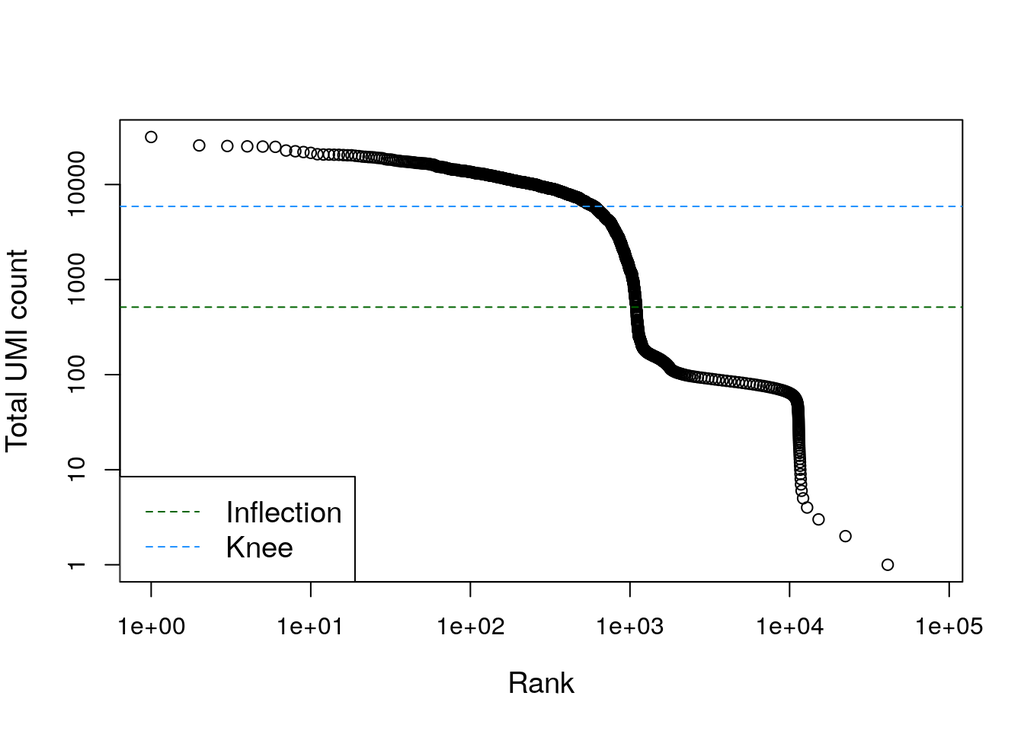

## Identify non-empty droplets

The *emptydrops* function can be used to identify good/bad droplets. 2 keys arguments are: - limit: lowest counts per cell - test.ambient: Could be used to estimate ambient RNA contamination

```r
set.seed(100)
limit <- 100
e.out <- emptyDrops(counts(sce), lower = limit, test.ambient = TRUE)
#
e.out
```

```
## DataFrame with 100000 rows and 5 columns
##                        Total     LogProb     PValue   Limited         FDR
##                    <integer>   <numeric>  <numeric> <logical>   <numeric>
## CGTGTCTTCGCATGAT-1         1    -5.34170 0.70912909     FALSE          NA
## TTTATGCGTCGAACAG-1         1    -6.44503 0.50414959     FALSE          NA
## CATGACACAAGTCTGT-1         0          NA         NA        NA          NA
## ACATACGCACCACCAG-1        58  -266.20222 0.01839816     FALSE          NA
## CGTCCATAGCTGCAAG-1      1601 -2917.18710 0.00009999      TRUE 0.000200166
## ...                      ...         ...        ...       ...         ...
## GTGCTTCGTCACCCAG-1         0          NA         NA        NA          NA
## GGAAAGCCAAGGCTCC-1         1    -9.06371 0.20007999     FALSE          NA
## TGCCCTAGTAGCTCCG-1         1   -13.51757 0.00309969     FALSE          NA
## TTATGCTGTGTTTGTG-1         0          NA         NA        NA          NA
## GCTGCGACACGTTGGC-1         0          NA         NA        NA          NA
```

## Identify non-empty droplets

```r
# Testeed by FDR
summary(e.out$FDR <= 0.001)
```

```
##    Mode   FALSE    TRUE    NA's
## logical    1072    1080   97848
```

```r
# Concordance by testing with FDR and limited
table(Sig = e.out$FDR <= 0.001, Limited = e.out$Limited)
```

```
##        Limited
## Sig     FALSE TRUE
##   FALSE  1072    0
##   TRUE      6 1074
```

## Distribution of non-empty reads

We can plot the distribution of significance of non-empty reads

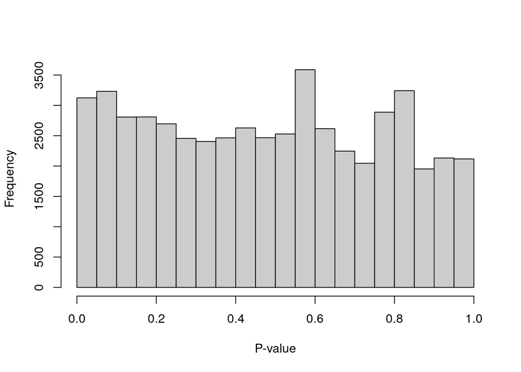

```r
hist(e.out$PValue[e.out$Total <= limit & e.out$Total > 0], xlab = "P-value", main = "",
    col = "grey80")
```

## Subset non-empty droplets

We can filter to just our non-empty droplets using a simple which query on the FDR from *emptyDrops()*. Here we are using a 0.001 cut-off.

```r
sce2 <- sce[, which(e.out$FDR <= 0.001)]
```

# Normalization and clustering

## Counts normalization

```r
library(scran)
library(scuttle)
library(scater)
clusters <- quickCluster(sce2)
sce2 <- computeSumFactors(sce2, cluster = clusters)
sce2 <- logNormCounts(sce2)
sce2
```

```
## class: SingleCellExperiment
## dim: 27998 1080
## metadata(1): Samples
## assays(2): counts logcounts
## rownames(27998): ENSMUSG00000051951 ENSMUSG00000089699 ...
##   ENSMUSG00000096730 ENSMUSG00000095742
## rowData names(2): ID Symbol
## colnames(1080): CGTCCATAGCTGCAAG-1 GCTCCTAAGGCACATG-1 ...
##   ACTGAGTCACACCGAC-1 GAACGGAAGCTTATCG-1
## colData names(3): Sample Barcode sizeFactor
## reducedDimNames(0):
## mainExpName: NULL
## altExpNames(0):
```

## Identify variable features

```r
set.seed(1000)
# modeling variables
dec.pbmc <- modelGeneVarByPoisson(sce2)
# calcualte top features
top.pbmc <- getTopHVGs(dec.pbmc, prop = 0.1)
```

## Make TSNE and UMAP plots

```r
set.seed(1000)
# Evaluate PCs
sce2 <- denoisePCA(sce2, subset.row = top.pbmc, technical = dec.pbmc)
# make TSNE plot
sce2 <- runTSNE(sce2, dimred = "PCA")
# make UMAP plot
sce2 <- runUMAP(sce2, dimred = "PCA")
```

## Graphic based clustering

```r
g <- buildSNNGraph(sce2, k = 10, use.dimred = "PCA")
clust <- igraph::cluster_walktrap(g)$membership
colLabels(sce2) <- factor(clust)
#
colData(sce2)
```

```
## DataFrame with 1080 rows and 4 columns
##                                    Sample            Barcode sizeFactor
##                               <character>        <character>  <numeric>
## CGTCCATAGCTGCAAG-1 ~/Desktop/01_scSeq_t.. CGTCCATAGCTGCAAG-1   0.220604
## GCTCCTAAGGCACATG-1 ~/Desktop/01_scSeq_t.. GCTCCTAAGGCACATG-1   1.293722
## CGGACACAGTACGACG-1 ~/Desktop/01_scSeq_t.. CGGACACAGTACGACG-1   0.477037
## GTAACTGTCGGATGGA-1 ~/Desktop/01_scSeq_t.. GTAACTGTCGGATGGA-1   1.411181
## TGACTAGAGTAGGCCA-1 ~/Desktop/01_scSeq_t.. TGACTAGAGTAGGCCA-1   0.394843
## ...                                   ...                ...        ...
## ACGATACCAATGCCAT-1 ~/Desktop/01_scSeq_t.. ACGATACCAATGCCAT-1   0.392299
## AGGTCATCATGTAAGA-1 ~/Desktop/01_scSeq_t.. AGGTCATCATGTAAGA-1   2.538163
## CCGGGATAGCCACCTG-1 ~/Desktop/01_scSeq_t.. CCGGGATAGCCACCTG-1   0.261304
## ACTGAGTCACACCGAC-1 ~/Desktop/01_scSeq_t.. ACTGAGTCACACCGAC-1   0.363430
## GAACGGAAGCTTATCG-1 ~/Desktop/01_scSeq_t.. GAACGGAAGCTTATCG-1   0.656362
##                       label
##                    <factor>
## CGTCCATAGCTGCAAG-1        4
## GCTCCTAAGGCACATG-1        3
## CGGACACAGTACGACG-1        5
## GTAACTGTCGGATGGA-1        3
## TGACTAGAGTAGGCCA-1        5
## ...                     ...
## ACGATACCAATGCCAT-1        2
## AGGTCATCATGTAAGA-1        3
## CCGGGATAGCCACCTG-1        2
## ACTGAGTCACACCGAC-1        1
## GAACGGAAGCTTATCG-1        3
```

## UMAP plot

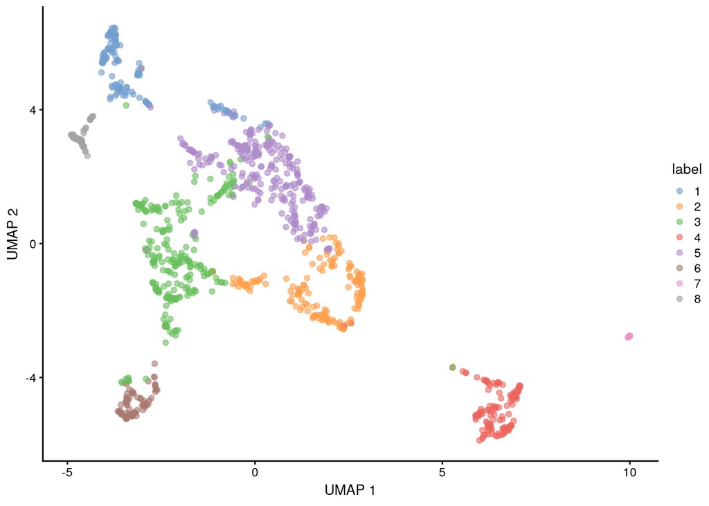

```r
plotUMAP(sce2, colour_by = "label")
```

## tSNE plot

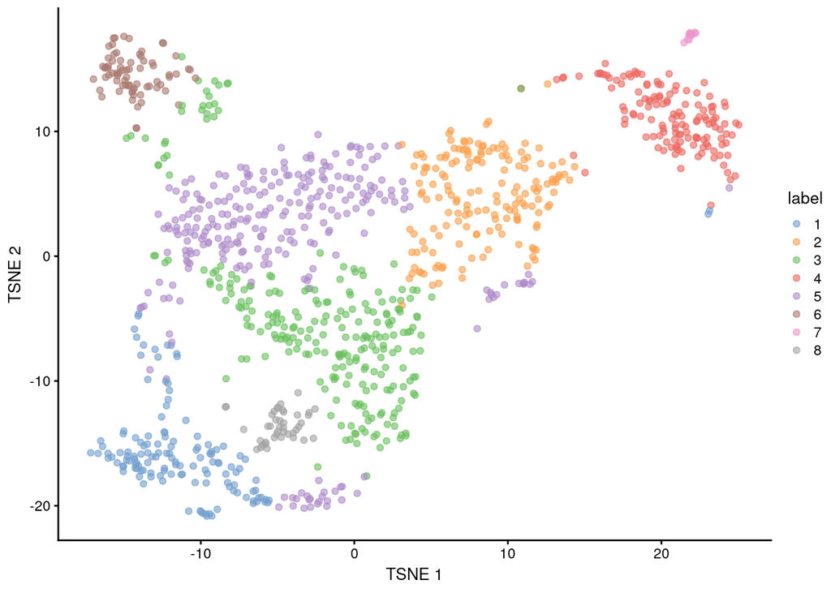

```r
plotTSNE(sce2, colour_by = "label")
```

# Removing Ambient RNA

## Ambient RNA

- Cell-free RNAs can contaminate droplets.
- They can be estimated by empty droplets.

```r
# extrat potential ambient RNA and thee estimated score
amb <- metadata(e.out)$ambient[, 1]
head(amb)
```

```
## ENSMUSG00000051951 ENSMUSG00000025902 ENSMUSG00000033845 ENSMUSG00000025903
##       5.808442e-07       5.808442e-07       1.067188e-04       6.783426e-05
## ENSMUSG00000033813 ENSMUSG00000002459
##       5.876210e-05       5.808442e-07
```

## Remove ambient RNA

```r
library(scater)
stripped <- sce2[names(amb), ]
out <- removeAmbience(counts(stripped), ambient = amb, groups = colLabels(stripped))
```

## Integrate corrected counts

```r
counts(stripped, withDimnames = FALSE) <- out
stripped <- logNormCounts(stripped)
```

## Before/After removal

- Hemoglobin A1 (Hba-a1) as example
- In most cases the Hbs are contaminated from residual RBCs

```r
ensmbl_id <- rowData(sce2)$ID[rowData(sce2)$Symbol == "Hba-a1"]
plotExpression(sce2, x = "label", colour_by = "label", features = ensmbl_id) + ggtitle("Before")

plotExpression(stripped, x = "label", colour_by = "label", features = ensmbl_id) +
    ggtitle("After")
```

## Before/After removal

Hemoglobin A1 (Hba-a1) as example

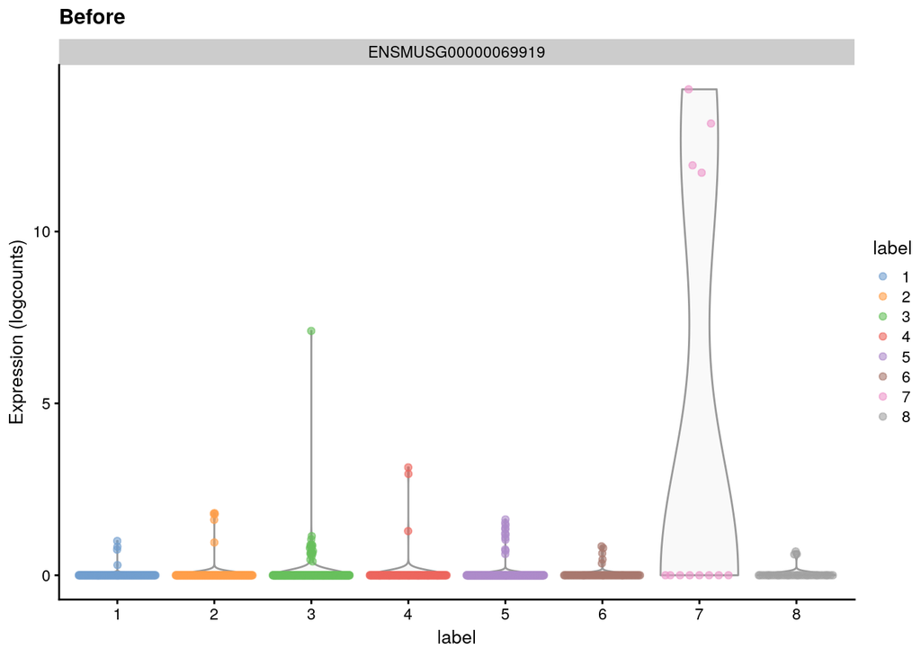

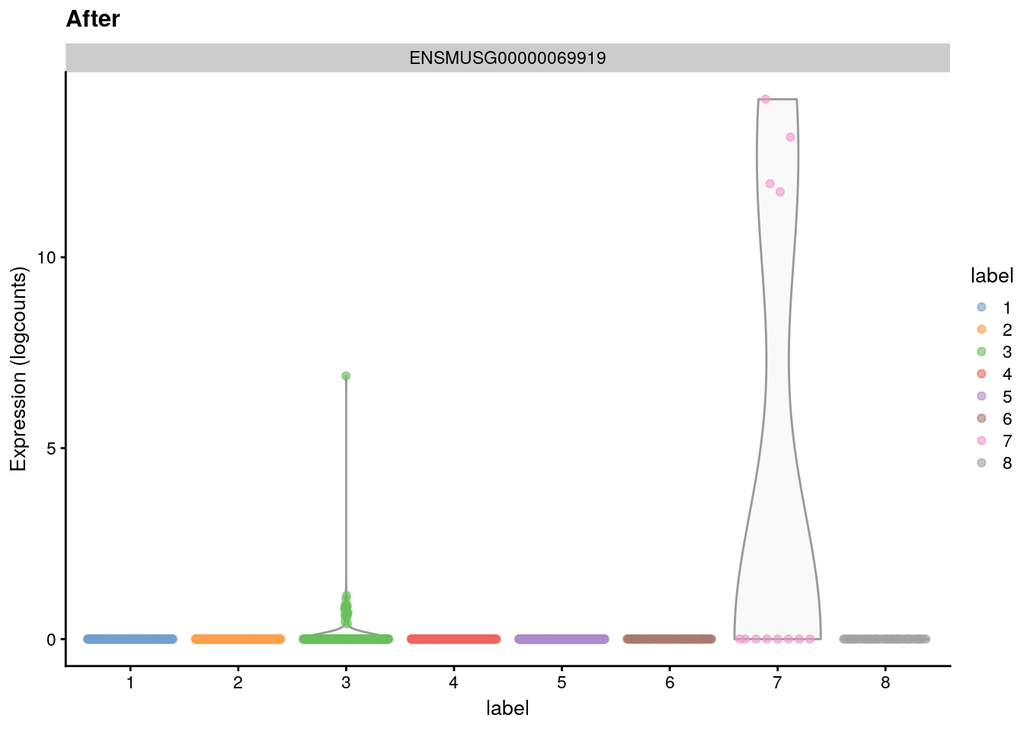

## Before/After removal

- Krt17 as example

```r
ensmbl_id <- rowData(sce2)$ID[rowData(sce2)$Symbol == "Krt17"]
plotExpression(sce2, x = "label", colour_by = "label", features = ensmbl_id) + ggtitle("Before")
plotExpression(stripped, x = "label", colour_by = "label", features = ensmbl_id) +
    ggtitle("After")
```

## Before/After removal

Krt17 as example

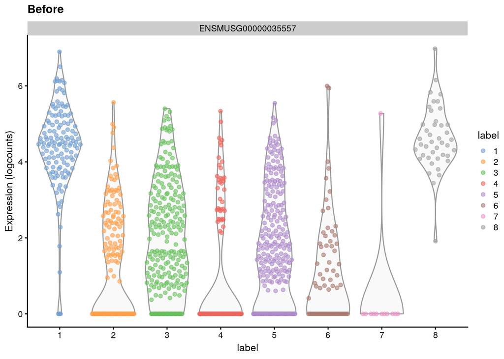

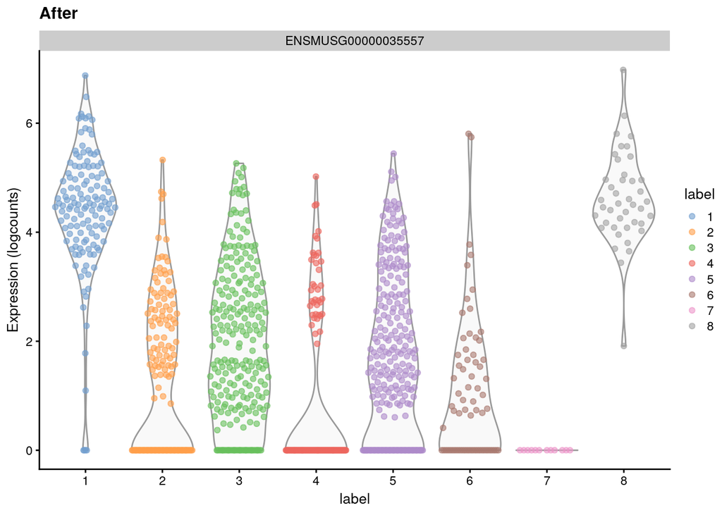

## Normalization and clustering

```r
dec <- modelGeneVar(stripped)
hvgs <- getTopHVGs(dec, n = 1000)
stripped <- runPCA(stripped, ncomponents = 10, subset_row = hvgs)
stripped <- runUMAP(stripped, dimred = "PCA")
g <- buildSNNGraph(stripped, k = 10, use.dimred = "PCA")
clust <- igraph::cluster_walktrap(g)$membership
colLabels(stripped) <- factor(clust)
plotUMAP(stripped, colour_by = "label")
```

## Normalization and clustering

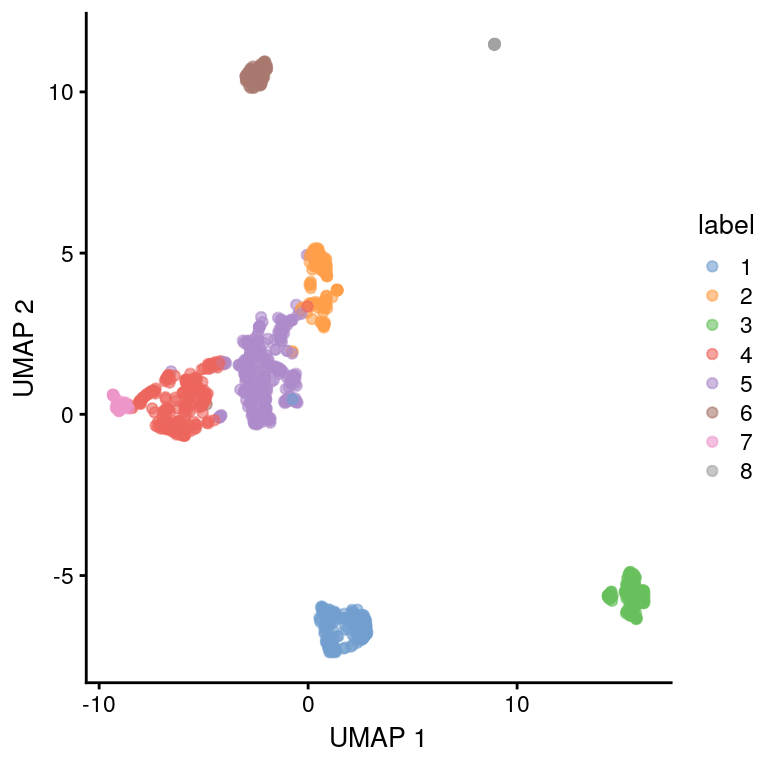

## Save result

Again we can save our results for later using a Rds object.

```r
saveRDS(stripped, "data/scSeq_CTRL_sceSub_rmAmbRNA.rds")
```

# Removing Doublets

## Doublets

- Doublets means two or more cells clumped in a single droplet. Thus, the read counts and genes detected in this droplet would be much higher than other droplets.
- Here, we demonstrate how to identify doublets using simulation with [scran](https://bioconductor.org/packages/release/bioc/manuals/scran/man/scran.pdf)

## Estimate doublets

The *computeDoubletDensity()* fucntion can be used on your SingleCellExperiment object to estimate doublets.

```r
dbl.dens <- computeDoubletDensity(stripped, #subset.row=top.mam,
    d=ncol(reducedDim(stripped)),subset.row=hvgs)
summary(dbl.dens)
```

```
##    Min. 1st Qu.  Median    Mean 3rd Qu.    Max.
##  0.0324  0.5011  0.9396  1.0330  1.4796  4.5122
```

```r
stripped$DoubletScore <- dbl.dens
```

## Plot doublets scores ~ UMAP

We can project the doublet scores onto our UMPA to see if doublet correlates with the data distribution.

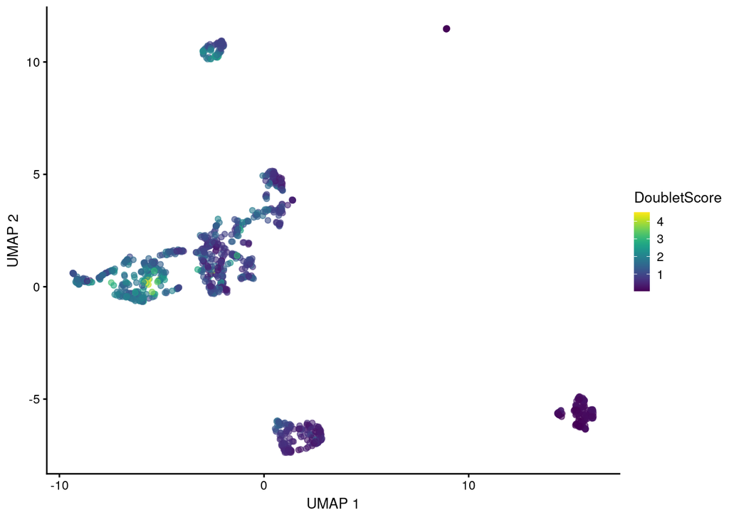

```r
plotUMAP(stripped, colour_by = "DoubletScore")
```

## Plot doublets scores by cluster

Likewise we can look for over representation of doublets in clusters.

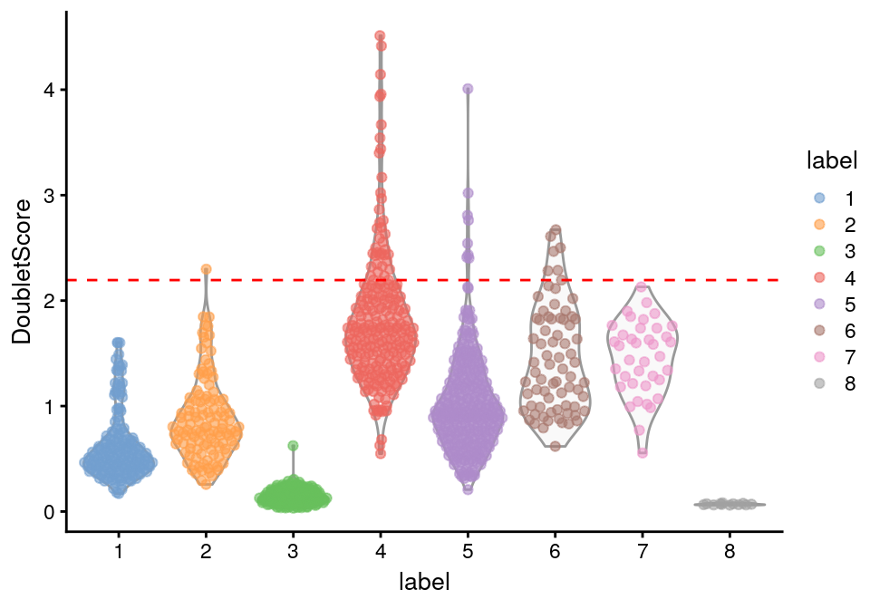

```r
plotColData(stripped, x = "label", y = "DoubletScore", colour_by = "label") + geom_hline(yintercept = quantile(colData(stripped)$DoubletScore,
    0.95), lty = "dashed", color = "red")
```

- No clusters have significantly higher doublet scores than other clusters. No clusters would be removed. - Red dash line represented 95% quantile of doublet score. The cells with higher doublet score than this cut-off would be removed.

## Remove doublets

We can clean our data up based on this 95% quantile cut-off.

```r
cut_off <- quantile(stripped$DoubletScore, 0.95)
stripped$isDoublet <- c("no", "yes")[factor(as.integer(stripped$DoubletScore >= cut_off),
    levels = c(0, 1))]
table(stripped$isDoublet)
```

```
##
##   no  yes
## 1025   55
```

```r
sce_clean <- stripped[stripped$isDoublet == "no", ]
saveRDS(sce_clean, "data/scSeq_CTRL_sceSub_rmAmbRNA_rmDoublet.rds")
```

# QC plots after clearance

## QC plots

- Mitochondrial content
- Genes detected
- Reads per cell

```r
library(scater)
mtGene <- rowData(sce_clean)$ID[grepl(rowData(sce_clean)$Symbol, pattern = "mt-")]
is.mito <- names(sce_clean) %in% mtGene
sce_clean <- addPerCellQC(sce_clean, subsets = list(Mito = is.mito))
```

## QC plots - Read counts

Post-clean

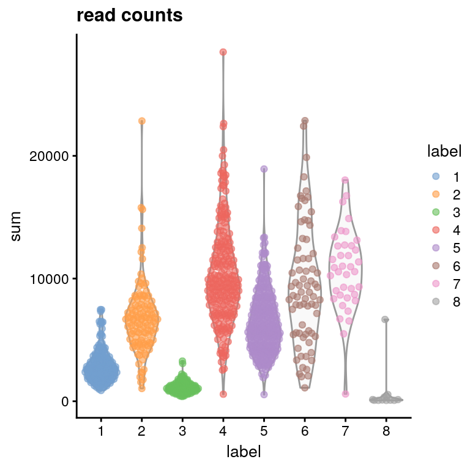

```r
plotColData(sce_clean, x = "label", y = "sum", colour_by = "label") + ggtitle("read counts")
```

## QC plots - Gene counts

Post-clean

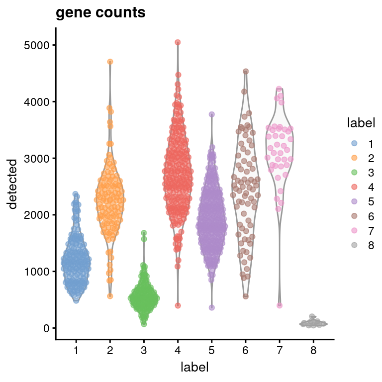

```r
plotColData(sce_clean, x = "label", y = "detected", colour_by = "label") + ggtitle("gene counts")
```

## QC plots - Mitochondrial %

Post-clean

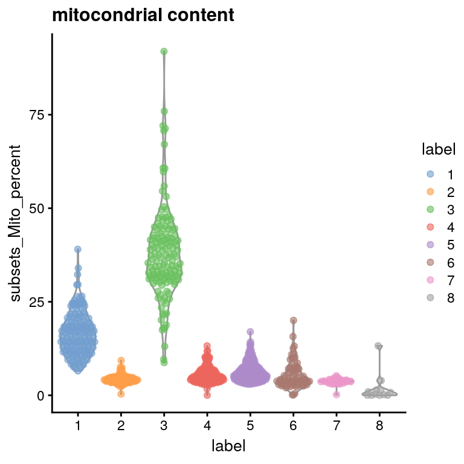

```r
plotColData(sce_clean, x = "label", y = "subsets_Mito_percent", colour_by = "label") +
    ggtitle("mitocondrial content")
```

## QC plots ~ comparison

- Mitochondrial contents vs read counts

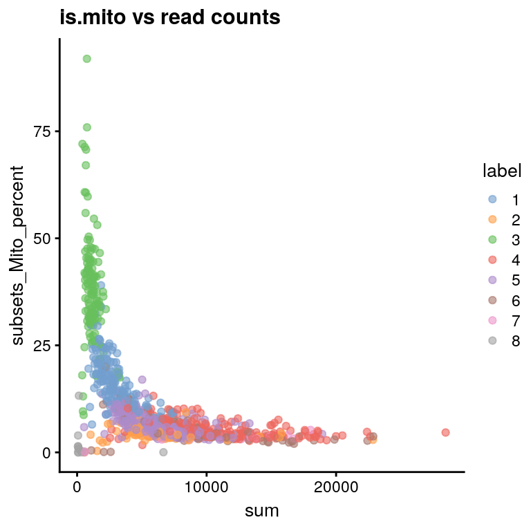

```r
plotColData(sce_clean, x = "sum", y = "subsets_Mito_percent", colour_by = "label") +
    ggtitle("is.mito vs read counts")
```

## QC plots ~ comparison

- Gene counts vs read counts

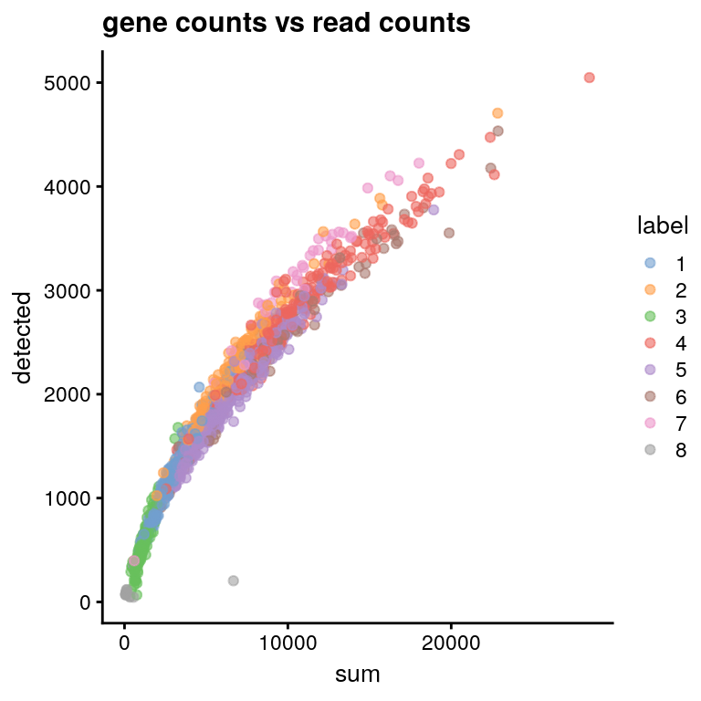

```r
plotColData(sce_clean, x = "sum", y = "detected", colour_by = "label") + ggtitle("gene counts vs read counts")
```

## Estimate variance explaination

- Clustering (label), mitochondrial content (subsets_Mito_percent), doublets (DoubletScore), read counts (sum), and gene counts (detected) were tested.
- We would suppose “label” (clustering) would explain more variances than other controls.

```r
vars <- getVarianceExplained(sce_clean, variables = c("DoubletScore", "label", "sum",
    "detected", "subsets_Mito_percent"))
```

```r
plotExplanatoryVariables(vars)
```

## Estimate variance explaination

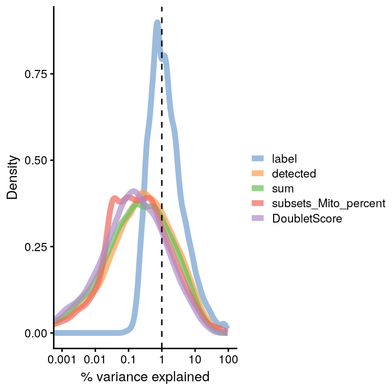

```r
plotExplanatoryVariables(vars)
```

## Time for an exercise!

Exercise on scRNAseq analysis with Bioconductor can be found here.

Answers can be found here.